# 5/26

LeeJunHyoung

2021 5 21

# 5/14 내용

# ANOVA test(분산분석)를 돌리기 위해 필요한 가정 2가지

## 1. 정규성 가정

## 2. 등분산 가정

- 등분산 가정이란 그룹 간 분산이 서로 같다는 것을 의미함.
- ANOVA는 그룹 간 변동과 그룹 내 변동을 이용해서 분석하는데 그룹 간 변동 > 그룹 내 변동이면 그룹 간 차이가 있다고 검정하는 것임.
- 등분산 가정이 만족되는 경우에만 ANOVA를 사용할 수 있음. (아닌 경우는 배제하겠음)
- 등분산 가정을 확인하는 검정으로 레빈(Levene’s test)과 바틀렛(Bartlett’s test) 검정을 많이 이용함

```r
a <- read.csv("C:/석사자료/석사수업자료/2021-1학기/통계소프트웨어실습조교/math.csv")
head(a)
```

```
##   gender math
## 1      1   84
## 2      1   78
## 3      1   95
## 4      1   78
## 5      1   96
## 6      1   51
```

```r
library(lawstat)
levene.test(a$math, a$gender, location = "mean")
```

```
##
##  Classical Levene's test based on the absolute deviations from the mean
##  ( none not applied because the location is not set to median )
##
## data:  a$math
## Test Statistic = 0.30135, p-value = 0.5874
```

```r
levene.test(a$math, a$gender, location = "median")
```

```
##
##  Modified robust Brown-Forsythe Levene-type test based on the absolute
##  deviations from the median
##
## data:  a$math
## Test Statistic = 0.14305, p-value = 0.7081
```

```r
bartlett.test(math ~ gender, data = a)
```

```
##
##  Bartlett test of homogeneity of variances
##
## data:  math by gender
## Bartlett's K-squared = 0.024949, df = 1, p-value = 0.8745
```

- 귀무가설 H0 : 등분산이다 vs H1 : 등분산이 아니다
- 위와 같은 가설로 검정했을 때 레빈 테스트는 평균과 중앙값을 기준으로 봐도 p-value 값이 0.05를 넘으므로 귀무가설을 기각할 수 없다. 즉 등분산이 아니라고 할 수 없다.
- 바틀렛 검정도 마찬가지로 p-value 값이 0.05를 초과하므로 귀무가설을 채택함.

# 독립 이표본 평균 비교 (Student’s t-test)

- 비교하고자 하는 두 변수(벡터)들을 종속변수(y)와 독립변수(x)로 표현함
- 이 test(t.test)를 진행할 때 ‘분산이 같지 않음’ 이 디폴트이므로 등분산 가정을 하기 위해 var.equal=T 를 넣어줌.
- var.test(y~x)는 기본적으로 등분산 가정을 함

```r
var.test(math ~ gender, data=a)
```

```
##
##  F test to compare two variances
##
## data:  math by gender
## F = 0.91765, num df = 14, denom df = 14, p-value = 0.8745
## alternative hypothesis: true ratio of variances is not equal to 1
## 95 percent confidence interval:
##  0.3080831 2.7333082
## sample estimates:
## ratio of variances
##          0.9176525
```

- var.test를 진행해보니 등분산성 가정이 위배되지 않는다.
- 그러므로 독립 이표본 평균 비교가 가능하다

```r
t.test(math ~ gender, data=a, var.equal=T)
```

```
##
##  Two Sample t-test
##
## data:  math by gender
## t = 0.2665, df = 28, p-value = 0.7918
## alternative hypothesis: true difference in means is not equal to 0
## 95 percent confidence interval:
##  -11.58944  15.05611
## sample estimates:
## mean in group 1 mean in group 2
##        75.93333        74.20000
```

- H0 : 평균이 같다(고 할 수 있다) vs H1 : 평균이 같지 않다.
- 가설검정결과 p-value값이 0.05보다 크므로 두 표본간 평균의 차이가 있다고 할 수 없다.

### 가설검정결과 설명 시 귀무가설을 기각하지 못함, 귀무가설을 기각 함 등으로 귀무가설 위주로 답안을 작성하시는 것이 좋습니다.

# 대응비교(Paired Comparison)

- 위에서는 두 표본(성별, 성적)이 독립일 때 그 자료의 차이에 의한 관계를 검정했음
- 대응비교는 동질적인 개체(X1,X2)들에 대한 검정임.
- 식에서는 D=X-Y라고 하며 저 D를 기준으로 일표본 검정을 진행함.

```r
pre <- c(77,56,64,60,58,72,67,78,67,79) # 열 명의 학생의 강의수강 전 성적
post <- c(99,80,78,65,59,67,65,85,74,80) # 강의수강 후 성적
t.test(pre, post, paired = T)
```

```
##
##  Paired t-test
##
## data:  pre and post
## t = -2.3906, df = 9, p-value = 0.04052
## alternative hypothesis: true difference in means is not equal to 0
## 95 percent confidence interval:
##  -14.4025448  -0.3974552
## sample estimates:
## mean of the differences
##                    -7.4
```

- H0 : 강의수강에 따른 성적차이가 없다. vs H1 : 차이가 있다.
- 가설 검정 결과 p-value값이 0.04로 0.05보다 작으므로 귀무가설을 기각한다.
- 즉, 강의수강에 따른 성적차이가 있다고 볼 수 있다.

# 5/21 내용용

# ANOVA test

- ANOVA test(이하 anova,아노바)는 셋 이상의 모집단에서 추출한 quantitive 자료들의 평균을 비교하기 위해 사용하는 분석방법임
- 분산을 사용함
- 위의 두 모집단 평균비교를 셋 이상으로 확장했다고 생각하면 됨

## 일원배치법(One-way ANOVA)

- 예를 들어, 재배한 사과 속의 비타민 함유량이 재배한 지역마다 다른지 확인하기 위해 여러 지역에서 사과를 뽑아 분석에 사용

```r
library(data.table)
```

```r
b <- data.frame(type=c("a","a","a","a","b","b","b","b","b","c","c","c","c","c","c"), score=c(12,17,10,14,13,15,18,16,21,11,30,28,26,29,27))
head(b)
```

```
##   type score
## 1    a    12
## 2    a    17
## 3    a    10
## 4    a    14
## 5    b    13
## 6    b    15
```

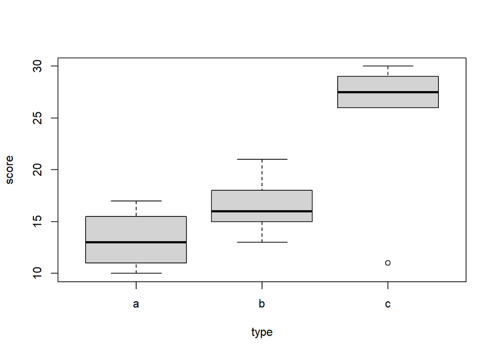

```r
boxplot(score ~ type, data=b)
```

- type 별 score 분포를 박스플랏으로 확인함.

```r
mod1 <- aov(score ~ type, data=b)
summary(mod1)
```

```
##             Df Sum Sq Mean Sq F value  Pr(>F)
## type         2  389.0  194.48   7.414 0.00801 **
## Residuals   12  314.8   26.23
## ---
## Signif. codes:  0 '***' 0.001 '**' 0.01 '*' 0.05 '.' 0.1 ' ' 1
```

- data=b에서 type별로 score를 아노바 분석을 진행하고 요약함 (ANOVA 테이블만 나옴)
- 타입이 a,b,c 세개이므로 자유도는 n-1 인 2가 되고 p-value값이 0.008임을 확인할 수 있음
- 이것은 타입별로 score의 차이가 유의미함을 뜻함.

```r
summary.lm(mod1)
```

```
##
## Call:
## aov(formula = score ~ type, data = b)
##
## Residuals:
##      Min       1Q   Median       3Q      Max
## -14.1667  -1.4250   0.8333   3.2917   4.8333
##
## Coefficients:
##             Estimate Std. Error t value Pr(>|t|)
## (Intercept)   13.250      2.561   5.174 0.000232 ***
## typeb          3.350      3.436   0.975 0.348786
## typec         11.917      3.306   3.605 0.003616 **
## ---
## Signif. codes:  0 '***' 0.001 '**' 0.01 '*' 0.05 '.' 0.1 ' ' 1
##
## Residual standard error: 5.122 on 12 degrees of freedom
## Multiple R-squared:  0.5527, Adjusted R-squared:  0.4781
## F-statistic: 7.414 on 2 and 12 DF,  p-value: 0.00801
```

```r
summary.lm
```

[output not shown]

[output cut: 46 more lines]

[output not shown]

- summary.lm은 회귀분석을 진행한 것의 요약을 확인한다는 의미
- type A를 기준으로(0으로) b, c의 차이가 3.35, 11.917정도 됨을 추정함

```r
fit.lm <- lm(score ~ type, data=b)
anova(fit.lm)
```

```
## Analysis of Variance Table
##
## Response: score
##           Df Sum Sq Mean Sq F value  Pr(>F)
## type       2 388.95 194.475  7.4137 0.00801 **
## Residuals 12 314.78  26.232
## ---
## Signif. codes:  0 '***' 0.001 '**' 0.01 '*' 0.05 '.' 0.1 ' ' 1
```

- aov()로 만들어준 데이터를 summary() 돌린 것이 anova()의 결과와 같음

## 이원배치법 (Two-way ANOVA)

```r
c <- read.csv("C:/석사자료/석사수업자료/2021-1학기/통계소프트웨어실습조교/vit.csv")
head(c)
```

```
##   variety area   vit
## 1       1    1 28.53
## 2       2    1 29.27
## 3       3    1 21.54
## 4       4    1 31.34
## 5       1    2 27.14
## 6       2    2 21.54
```

- 품종 별, 지역 별 vit값이 나열됨

```r
fit.lm2 <- lm(vit ~ as.factor(variety) + as.factor(area), data=c)
anova(fit.lm2)
```

```
## Analysis of Variance Table
##
## Response: vit
##                    Df  Sum Sq Mean Sq F value  Pr(>F)
## as.factor(variety)  3 109.142  36.381  5.4906 0.03722 *
## as.factor(area)     2   8.286   4.143  0.6252 0.56671
## Residuals           6  39.756   6.626
## ---
## Signif. codes:  0 '***' 0.001 '**' 0.01 '*' 0.05 '.' 0.1 ' ' 1
```

- H0 : 생산지역에 따른 vit값이 차이가 없다 vs H1 : ~ 차이가 있다.
- ANOVA 테이블을 통해서 값을 확인하면 area에 따른 p-value값은 0.05보다 크므로 귀무가설 기각못함.
- H0 : 품종에 따른 vit값이 차이가 없다 vs H1 : ~ 차이가 있다.
- ANOVA 테이블을 통한 값을 확인하면 variety에 따른 p-value값은 0.05보다 작으므로 귀무가설 기각함.

## 다중비교(Multiple comparison)

```r
TukeyHSD(mod1, "type")
```

```
##   Tukey multiple comparisons of means
##     95% family-wise confidence level
##
## Fit: aov(formula = score ~ type, data = b)
##
## $type
##          diff        lwr      upr     p adj
## b-a  3.350000 -5.8161114 12.51611 0.6056307
## c-a 11.916667  3.0965719 20.73676 0.0093673
## c-b  8.566667  0.2926844 16.84065 0.0423324
```

- 각 타입별로 차이가 얼마나 나는지 확인함
- Tukey 방법으로 C는 a와 b의 차이가 유의함을 확인함(p-value<0.05)

```r
pairwise.t.test(b$score, b$type, p.adj="bonferroni")
```

```
##
##  Pairwise comparisons using t tests with pooled SD
##
## data:  b$score and b$type
##
##   a     b
## b 1.000 -
## c 0.011 0.052
##
## P value adjustment method: bonferroni
```

```r
library(multcomp)
b$type <- as.factor(b$type)
mod2 <- aov(score ~ type, data = b)
out <- glht(mod2, linfct=mcp(type="Tukey"))
summary(out)
```

```
##
##   Simultaneous Tests for General Linear Hypotheses
##
## Multiple Comparisons of Means: Tukey Contrasts
##
##
## Fit: aov(formula = score ~ type, data = b)
##
## Linear Hypotheses:
##            Estimate Std. Error t value Pr(>|t|)
## b - a == 0    3.350      3.436   0.975   0.6052
## c - a == 0   11.917      3.306   3.605   0.0094 **
## c - b == 0    8.567      3.101   2.762   0.0422 *
## ---
## Signif. codes:  0 '***' 0.001 '**' 0.01 '*' 0.05 '.' 0.1 ' ' 1
## (Adjusted p values reported -- single-step method)
```